# EDA IN R

#### Cheking for duplicates

```r
sum(duplicated(ad))
```

```
## [1] 0
```

##### We have no duplicates in this dataset

#### Cheking for Missing values in the dataset

```r
colSums(is.na(ad))
```

```
## Daily.Time.Spent.on.Site                      Age              Area.Income
##                        0                        0                        0
##     Daily.Internet.Usage            Ad.Topic.Line                     City
##                        0                        0                        0
##                     Male                  Country                Timestamp
##                        0                        0                        0
##            Clicked.on.Ad
##                        0
```

##### The dataset contains no missing values

### EDA

#### UNIVARIATE ANALYSIS

```r
summary(ad)
```

```
##  Daily.Time.Spent.on.Site      Age         Area.Income    Daily.Internet.Usage
##  Min.   :32.60            Min.   :19.00   Min.   :13996   Min.   :104.8
##  1st Qu.:51.36            1st Qu.:29.00   1st Qu.:47032   1st Qu.:138.8
##  Median :68.22            Median :35.00   Median :57012   Median :183.1
##  Mean   :65.00            Mean   :36.01   Mean   :55000   Mean   :180.0
##  3rd Qu.:78.55            3rd Qu.:42.00   3rd Qu.:65471   3rd Qu.:218.8
##  Max.   :91.43            Max.   :61.00   Max.   :79485   Max.   :270.0
##  Ad.Topic.Line          City                Male         Country
##  Length:1000        Length:1000        Min.   :0.000   Length:1000
##  Class :character   Class :character   1st Qu.:0.000   Class :character
##  Mode  :character   Mode  :character   Median :0.000   Mode  :character
##                                        Mean   :0.481
##                                        3rd Qu.:1.000
##                                        Max.   :1.000
##   Timestamp         Clicked.on.Ad
##  Length:1000        Min.   :0.0
##  Class :character   1st Qu.:0.0
##  Mode  :character   Median :0.5
##                     Mean   :0.5
##                     3rd Qu.:1.0
##                     Max.   :1.0
```

##### From the above we can see the mean, median and the min for our numerical columns

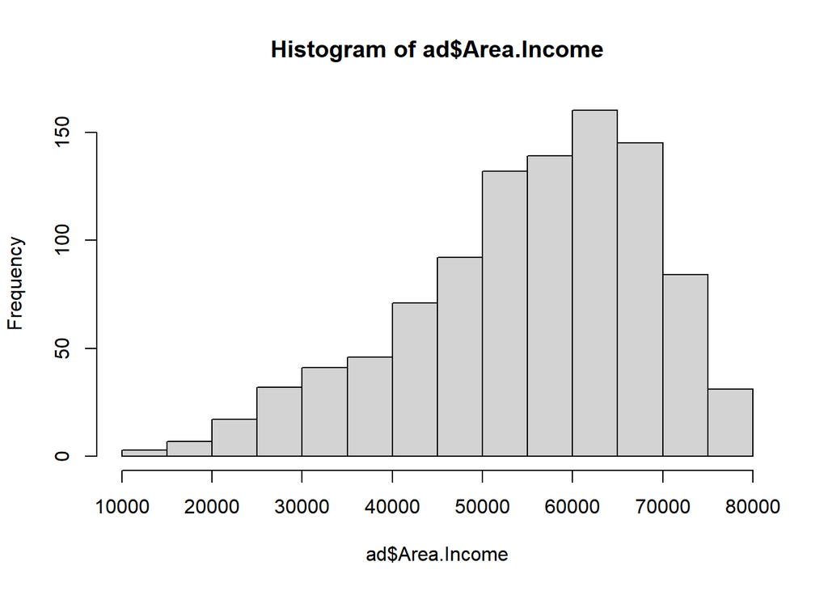

```r
### Calculating the Spread of our columns and skewness
hist(ad$Area.Income)
```

##### From the above spread of our Area.income column we can see that it is negatively skewed meaning that most of the data points lie towards the neagtive

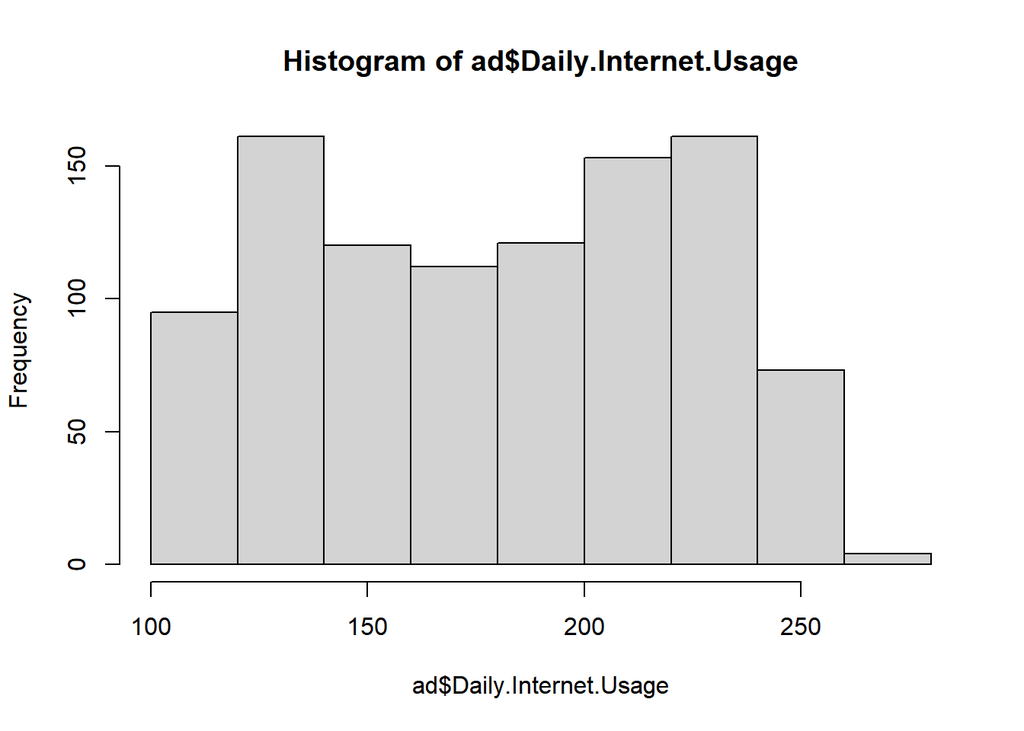

```r
### Calculating the Spread of our columns and skewness
hist(ad$Daily.Internet.Usage)
```

#### We can see that the Daily internet Usage has somewhat of a symmetrical distribution or rather the spread of the data is neither positvely nor negatively skewed

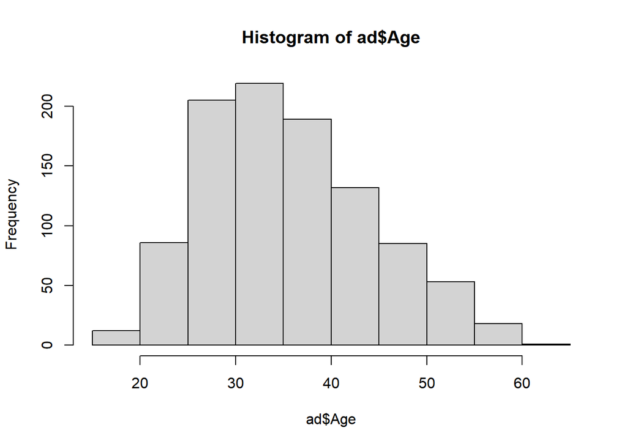

```r
### Calculating the Spread of our columns and skewness
hist(ad$Age)
```

##### Age seems to be positvely skewed but it is still not quite clear from the spread above

#### BIVARIATE ANALYSIS

```r
### Checking the correlation of our age to the target column which is the clicked on ad
cor.test(ad$Age, ad$Clicked.on.Ad, method = "pearson")
```

```
##
##  Pearson's product-moment correlation
##
## data:  ad$Age and ad$Clicked.on.Ad
## t = 17.879, df = 998, p-value < 2.2e-16
## alternative hypothesis: true correlation is not equal to 0
## 95 percent confidence interval:
##  0.4440981 0.5380944
## sample estimates:
##       cor
## 0.4925313
```

##### From the above we can see that Age and Clicked on Ad have a fairly moderate positive correlation at 0.49

```r
### Checking the correlation of our Area.Income to the target column which is the clicked on ad
cor.test(ad$Area.Income, ad$Clicked.on.Ad, method = "pearson")
```

```
##
##  Pearson's product-moment correlation
##
## data:  ad$Area.Income and ad$Clicked.on.Ad
## t = -17.111, df = 998, p-value < 2.2e-16
## alternative hypothesis: true correlation is not equal to 0
## 95 percent confidence interval:
##  -0.5228120 -0.4268645
## sample estimates:
##        cor
## -0.4762546
```

##### From the above we can see thatArea.Income and Clicked on Ad have a fairly moderate negative correlation at -0.47

#### PLOTTING THE CORRELATION OF THE REST OF THE VARIABLES

```r
cor(Filter(is.numeric, ad))
```

```
##                          Daily.Time.Spent.on.Site         Age  Area.Income
## Daily.Time.Spent.on.Site               1.00000000 -0.33151334  0.310954413
## Age                                   -0.33151334  1.00000000 -0.182604955
## Area.Income                            0.31095441 -0.18260496  1.000000000
## Daily.Internet.Usage                   0.51865848 -0.36720856  0.337495533
## Male                                  -0.01895085 -0.02104406  0.001322359
## Clicked.on.Ad                         -0.74811656  0.49253127 -0.476254628
##                          Daily.Internet.Usage         Male Clicked.on.Ad
## Daily.Time.Spent.on.Site           0.51865848 -0.018950855   -0.74811656
## Age                               -0.36720856 -0.021044064    0.49253127
## Area.Income                        0.33749553  0.001322359   -0.47625463
## Daily.Internet.Usage               1.00000000  0.028012326   -0.78653918
## Male                               0.02801233  1.000000000   -0.03802747
## Clicked.on.Ad                     -0.78653918 -0.038027466    1.00000000
```

##### The last column that has the correlation comapring the columns with the target column is the most intresting as we can see for example Daily.Time.Spent.on.Site and Clicked.on.Ad have a very strong negative correlation at -0.74

##### VISULAISING THE CORRELATIONS

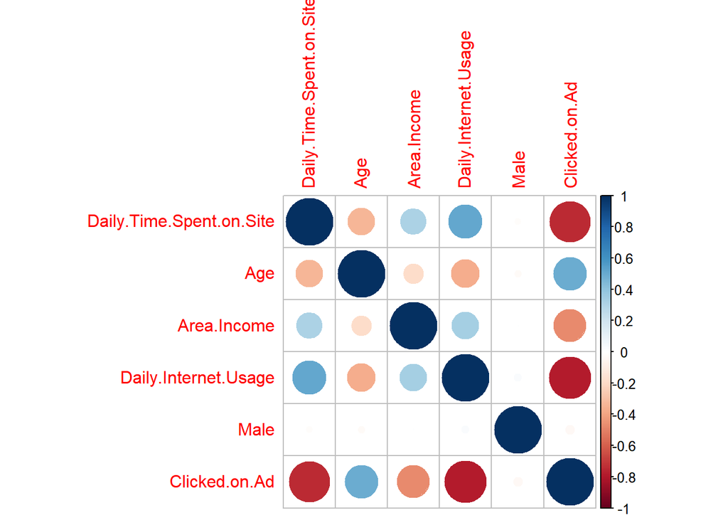

```r
install.packages("corrplot")
library(corrplot)
adnumerical <- Filter(is.numeric, ad)
corrplot(cor(adnumerical))
```

##### HISTOGRAMS

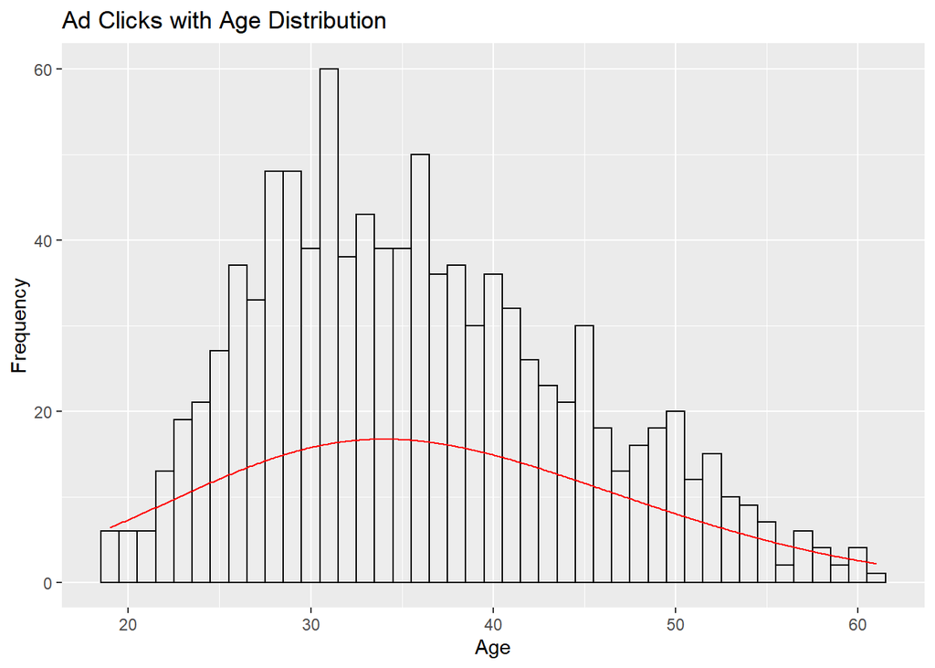

```r
library(ggplot2)

ggplot(data = ad, aes(x = Age, fill = Clicked.on.Ad))+
    geom_histogram(binwidth = 1, color = 'black', fill = "white", alpha = 0.1) +  geom_density(aes(y=0.5*..count..), colour="red", adjust=4) +
    labs(title = 'Ad Clicks with Age Distribution', x = 'Age', y = 'Frequency', fill = 'Clicked.on.Ad')
```

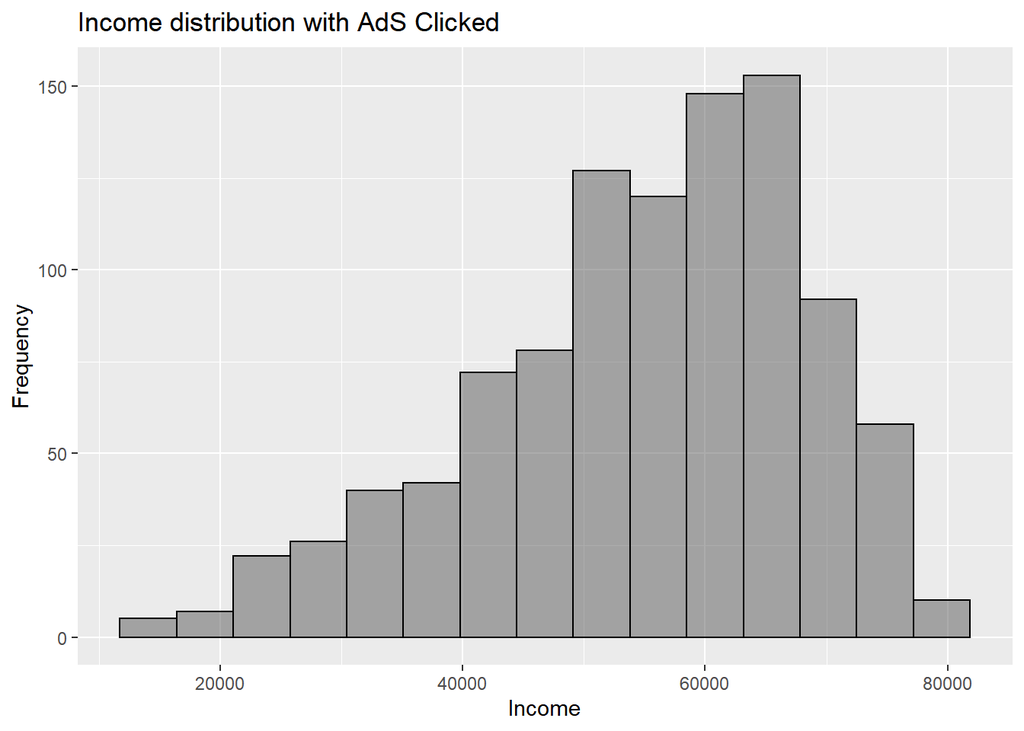

```r
library(ggplot2)
ggplot(data = ad, aes(x = Area.Income, fill = Clicked.on.Ad))+
    geom_histogram(bins = 15,color = 'black',  alpha = 0.5) +
    labs(title = 'Income distribution with AdS Clicked', x = 'Income', y = 'Frequency', fill = 'Clicked.on.Ad')
```

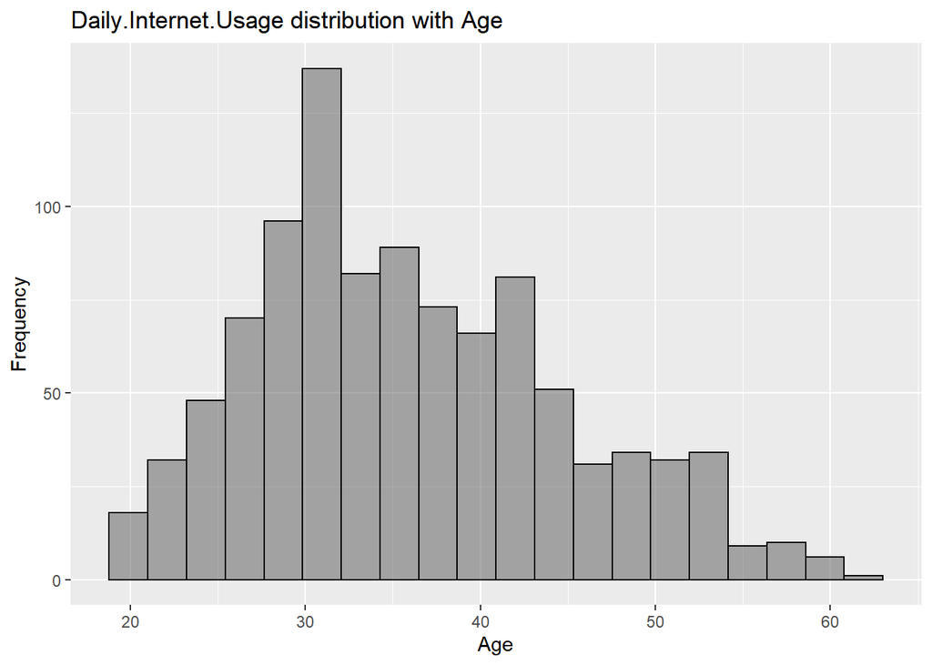

```r
library(ggplot2)
ggplot(data = ad, aes(x = Age, fill = Daily.Internet.Usage))+
    geom_histogram(bins = 20,color = 'black',  alpha = 0.5) +
    labs(title = 'Daily.Internet.Usage distribution with Age', x = 'Age', y = 'Frequency', fill = 'Daily.Internet.Usage')
```

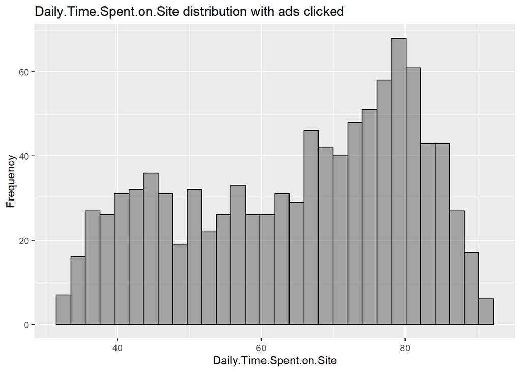

```r
library(ggplot2)
ggplot(data = ad, aes(x = Daily.Time.Spent.on.Site, fill = Clicked.on.Ad))+
    geom_histogram(bins = 30,color = 'black',  alpha = 0.5) +
    labs(title = 'Daily.Time.Spent.on.Site distribution with ads clicked', x = 'Daily.Time.Spent.on.Site', y = 'Frequency', fill = 'Clicked.on.Ad')
```

### Conclusions

[output not shown]

###Recommendations

[output not shown]

```r
install.packages('plyr', repos = "http://cran.us.r-project.org")
```